# Milestone Report: Exploratory Analysis

Sandra Ezidiegwu

September 2, 2016

# Introduction

This is the milestone report for the Exploratory Analysis section of the Coursera Data Science Capstone project. The goal of this capstone project is to analyze a large corpus of text documents to discover the structure in the data and how words are put together. By cleaning and analyzing text data, I will then build a predictive text model.

This report will summarize the findings from the exploratory analysis carried out on data for the capstone project. I have included some major statistical findings and you will find below, graphs that are representative of the data set of words.

```r
library(R.utils)
library(stringi)
library(ggplot2)
library(ngram)
library(tm)
library(RWeka)
library(tau)
library(wordcloud)
```

## Data Processing

### Loading the Dataset

```r
setwd("/Users/sandraezidiegwu/Documents/Data Science/Capstone Project/final/en_US/")
swiftkey <- "https://d396qusza40orc.cloudfront.net/dsscapstone/dataset/Coursera-SwiftKey.zip"
download.file(swiftkey, destfile = "./SwiftKey", method = "curl")
unzip("SwiftKey")

blog <- readLines("en_US.blogs.txt", encoding = "UTF-8")
news <- readLines("en_US.news.txt", encoding = "UTF-8")
twitter <- readLines("en_US.twitter.txt", encoding = "UTF-8")
```

### Sample Data Collection

To reduce processing time, we will grab samples of the data.

```r
set.seed(124)
blog.s <- sample(blog, 1000)
news.s <- sample(news, 1000)
twitter.s <- sample(twitter, 1000)
```

### Combine Blog/News/Twitter Word Samples into 1 File

```r
words <- c(blog.s, news.s, twitter.s)
write(words, file = 'words.txt')
words <- readLines("words.txt")
```

## Summary Statistics

```
##        File Name File Size (mb) Line Count Word Count
## 1          Blogs         248.49     899288   37334131
## 2           News         249.63    1010242   34372530
## 3        Twitter         301.40    2360148   30373543
## 4 Sample Summary           0.66       3000      89476
```

### Summary Statistics Visualization

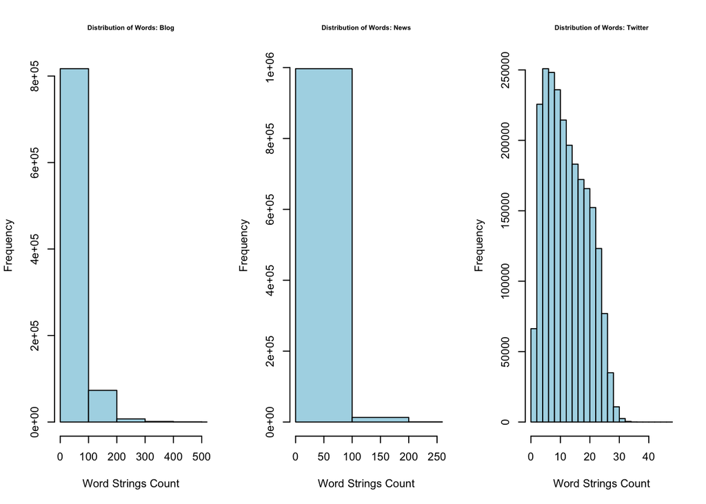

## Text Corpus and Cleaning

```r
words <- gsub("http.*\\s*", "", words)
words <- gsub("[[:punct:]]", "", words)
words <- gsub("[[:digit:]]", "", words)
words <- gsub("http[[:alnum:]]*", "", words)
words <- gsub("^\\s+|\\s+$", " ", words)

#Convert to Lower Case
words <- tolower(words)

#Remove Stopwords
words <- removeWords(words, stopwords(kind = "en"))

#Remove Profanity
words.profanity <- readLines("profanity.csv")
words <- removeWords(words, words.profanity)

#Create Corpus
words.corpus <- Corpus(VectorSource(words), readerControl = list(reader =  readPlain, language = 'en'))
```

### Tokenization

Using the ‘tau’ package, I will create functions that tokenize the text into unigrams, bigrams and trigrams

```r
unigramtoken <- function(x, n=1) return(rownames(as.data.frame(unclass(textcnt(x$content,method="string",n=n)))))
bigramtoken <- function(x, n=2) return(rownames(as.data.frame(unclass(textcnt(x$content,method="string",n=n)))))
trigramtoken <- function(x, n=3) return(rownames(as.data.frame(unclass(textcnt(x$content,method="string",n=n)))))
```

### Top 10 Unigrams/Bigrams/Trigrams

```r
tdm.unigram <- TermDocumentMatrix(words.corpus, control=list(tokenize=unigramtoken))
freq1 <- sort(rowSums(as.matrix(tdm.unigram)), decreasing = T)
freq.df1 <- data.frame(word=names(freq1), freq=freq1)
head(freq.df1, 10)
```

```
##      word freq
## said said  242
## will will  231
## one   one  215
## just just  212
## like like  184
## can   can  168
## get   get  152
## time time  141
## new   new  139
## now   now  135
```

```r
tdm.bigram <- TermDocumentMatrix(words.corpus, control=list(tokenize=bigramtoken))
freq2 <- sort(rowSums(as.matrix(tdm.bigram)), decreasing = T)
freq.df2 <- data.frame(word=names(freq2), freq=freq2)
head(freq.df2, 10)
```

```
##                    word freq
## high school high school   18
## new york       new york   16
## im going       im going   14
## last year     last year   14
## right now     right now   13
## st louis       st louis   13
## years ago     years ago   13
## first time   first time   12
## dont know     dont know   11
## dont think   dont think   10
```

```r
tdm.trigram <- TermDocumentMatrix(words.corpus, control=list(tokenize=trigramtoken))
freq3 <- sort(rowSums(as.matrix(tdm.trigram)), decreasing = T)
freq.df3 <- data.frame(word=names(freq3), freq=freq3)
head(freq.df3, 10)
```

```
##                                            word freq
## president barack obama   president barack obama    5
## new york times                   new york times    4
## im hard time                       im hard time    3
## also great way                   also great way    2
## can honestly say               can honestly say    2
## cant imagine youre           cant imagine youre    2
## cant wait share                 cant wait share    2
## columbia university new columbia university new    2
## couple weeks ago               couple weeks ago    2
## couple years ago               couple years ago    2
```

Wordcloud of most frequent words used in dataset

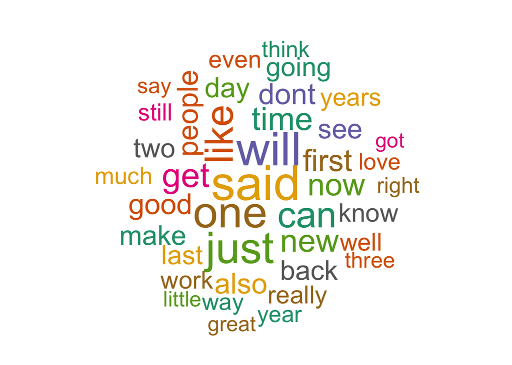

```r
wordcloud(freq.df1$word, freq.df1$freq, scale = c(4,0.8), max.words = 40, random.order = F, random.color = TRUE, colors = brewer.pal(8,'Dark2'))
```

## Findings and Further Work

- The twitter words string count vary differently from the news and blogs dues to the 140 character limitations set my twitter for each post.
- Data processing is terribly slow due to the size of the word files. It was necessary to reduce the size by taking samples.
- The lack of stopwords are needed for accurate prediction, in my following work, I will include stopwords.
- The next step would be building a prediction algorithm for my application.